# Homework 11

Ruolin Huang

2026-02-13

## Instructions

Answer the following questions and complete the exercises in RMarkdown. Please embed all of your code and push your final work to your repository. Your final lab report should be organized, clean, and run free from errors. Remember, you must remove the `#` for the included code chunks to run. Be sure to add your name to the author header above. For any included plots, make sure they are clearly labeled. You are free to use any plot type that you feel best communicates the results of your analysis.

Make sure to use the formatting conventions of RMarkdown to make your report neat and clean!

## Load the libraries

```r
library(tidyverse)
library(janitor)
```

```r
options(scipen = 999)
```

## Data

For this homework, we are going to use the [Gapminder](https://www.gapminder.org/data/) data on population (pop), GDP per capita (gdp), and life expectancy (lex). These data were downloaded and compiled using the `gapminder_compile.Rmd` script in the data folder.

Let’s focus our attention on data from the past 100 years, between 1925 and 2025.

```r
gapminder <- read_csv("data/gapminder.csv") %>%
  clean_names() %>%
  filter(between(year, 1925, 2025))
```

1. Use the function(s) of your choice to get an idea of the overall structure of the data, including its dimensions, column names, classes, etc.

```r
glimpse(gapminder)
```

```
## Rows: 19,695
## Columns: 5
## $ country <chr> "Afghanistan", "Afghanistan", "Afghanistan", "Afghanistan", "A…
## $ year    <dbl> 1925, 1926, 1927, 1928, 1929, 1930, 1931, 1932, 1933, 1934, 19…
## $ pop     <dbl> 8748779, 8289705, 7854721, 7442562, 7121951, 6888085, 6736411,…
## $ gdp     <dbl> 1113.793, 1127.866, 1142.117, 1156.548, 1171.161, 1185.959, 12…
## $ lex     <dbl> 38.87, 39.01, 39.16, 39.30, 39.44, 39.59, 39.73, 39.88, 40.02,…
```

```r
summary(gapminder)
```

```
##    country               year           pop                  gdp
##  Length:19695       Min.   :1925   Min.   :       651   Min.   :   316
##  Class :character   1st Qu.:1950   1st Qu.:    741871   1st Qu.:  2124
##  Mode  :character   Median :1975   Median :   3915338   Median :  4661
##                     Mean   :1975   Mean   :  22712317   Mean   : 12054
##                     3rd Qu.:2000   3rd Qu.:  12044477   3rd Qu.: 13082
##                     Max.   :2025   Max.   :1463865525   Max.   :475911
##                                    NA's   :25           NA's   :202
##       lex
##  Min.   : 4.18
##  1st Qu.:48.13
##  Median :61.91
##  Mean   :59.17
##  3rd Qu.:70.89
##  Max.   :85.63
##  NA's   :357
```

2. How many countries are represented in this dataset?

```r
gapminder %>%
  summarize(n_country=n_distinct(country))
```

```
## # A tibble: 1 × 1
##   n_country
##       <int>
## 1       195
```

3. Which five countries have had the largest absolute population growth between 1925-2025? Show this as a table.

```r
gapminder %>%
  filter(year==1925 | year==2025) %>%
  select(country, year, pop) %>%
  pivot_wider(names_from = "year",
              values_from = "pop") %>%
  mutate(pop_growth=`2025`-`1925`) %>%
  arrange(desc(pop_growth))
```

```
## # A tibble: 195 × 4
##    country       `1925`     `2025` pop_growth
##    <chr>          <dbl>      <dbl>      <dbl>
##  1 India      304406019 1463865525 1159459506
##  2 China      473741473 1416096094  942354621
##  3 Indonesia   49685263  285721236  236035973
##  4 Pakistan    22624808  255219554  232594746
##  5 USA        116193761  347275807  231082046
##  6 Nigeria     24779607  237527782  212748175
##  7 Brazil      30241952  212812405  182570453
##  8 Bangladesh  30286950  175686899  145399949
##  9 Ethiopia    17437296  135472051  118034755
## 10 Mexico      15509333  131946900  116437567
## # ℹ 185 more rows
```

OR

```r
gapminder %>%
  select(country, year, pop) %>%
  filter(year %in% c(1925, 2025)) %>%
  pivot_wider(names_from = "year",
              values_from = "pop",
              names_prefix = "pop_") %>%
  mutate(pop_growth=pop_2025-pop_1925) %>%
  arrange(desc(pop_growth))
```

```
## # A tibble: 195 × 4
##    country     pop_1925   pop_2025 pop_growth
##    <chr>          <dbl>      <dbl>      <dbl>
##  1 India      304406019 1463865525 1159459506
##  2 China      473741473 1416096094  942354621
##  3 Indonesia   49685263  285721236  236035973
##  4 Pakistan    22624808  255219554  232594746
##  5 USA        116193761  347275807  231082046
##  6 Nigeria     24779607  237527782  212748175
##  7 Brazil      30241952  212812405  182570453
##  8 Bangladesh  30286950  175686899  145399949
##  9 Ethiopia    17437296  135472051  118034755
## 10 Mexico      15509333  131946900  116437567
## # ℹ 185 more rows
```

4. Make a plot that shows population growth over time for the top country you found in question #3.

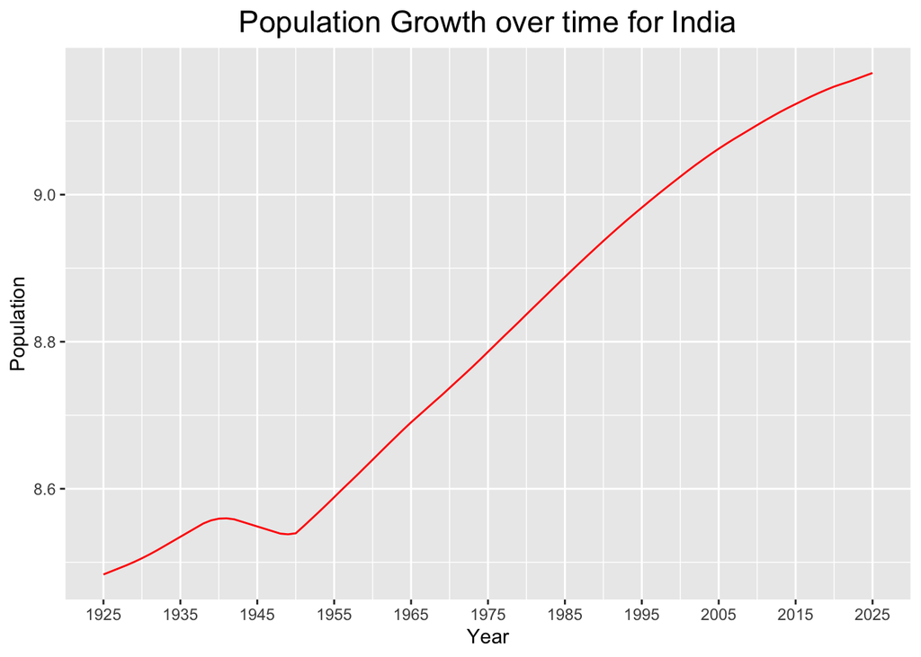

```r
gapminder %>%
  filter(country=="India") %>%
  ggplot(aes(x=year, y=log10(pop)))+
  geom_line(color="red")+
  scale_x_continuous(breaks=seq(1925, 2025, by=10))+
  labs(title="Population Growth over time for India", x="Year", y="Population")+
  theme(plot.title = element_text(size=rel(1.5), hjust=.5))
```

5. Has global life expectancy changed between 1925 and 2025? Show the min, median, mean, and max for all countries (combined) in the dataset.

```r
gapminder %>%
  filter(year %in% c(1925, 2025)) %>%
  group_by(year) %>%
  summarize(min_country=min(lex, na.rm=T),
            median_country=median(lex, na.rm=T),
            mean_country=mean(lex, na.rm=T),
            max_country=max(lex, na.rm=T))
```

```
## # A tibble: 2 × 5
##    year min_country median_country mean_country max_country
##   <dbl>       <dbl>          <dbl>        <dbl>       <dbl>
## 1  1925        21.0           35.9         38.1        63.5
## 2  2025        52.8           74.8         73.9        85.6
```

6. Make a plot that shows the distribution of life expectancy for all countries in 1925 and 2025 (try using `geom_density`). What do you notice about the shift in life expectancy over time?

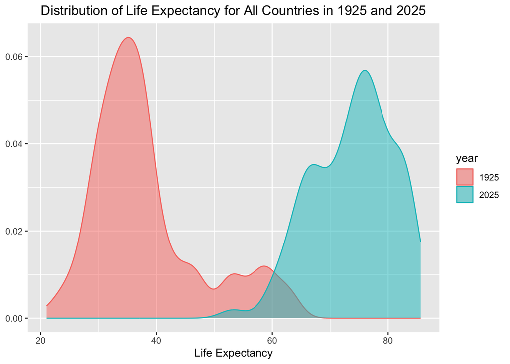

```r
gapminder %>%
  filter(year %in% c(1925, 2025)) %>%
  mutate(year=factor(year)) %>%
  ggplot(aes(x=lex, color=year, fill=year))+
  geom_density(alpha=0.5)+
  labs(title="Distribution of Life Expectancy for All Countries in 1925 and 2025", x="Life Expectancy", y=NULL)+
  theme(plot.title = element_text(hjust=.5))
```

The distribution of the life expectancy shifts to the right.

7. We are interested in the relationship between per capita GDP and life expectancy; i.e. does having more money help you live longer in 2025? Show this as a plot. (Suggestion! Remove Monaco as an extreme outlier.)

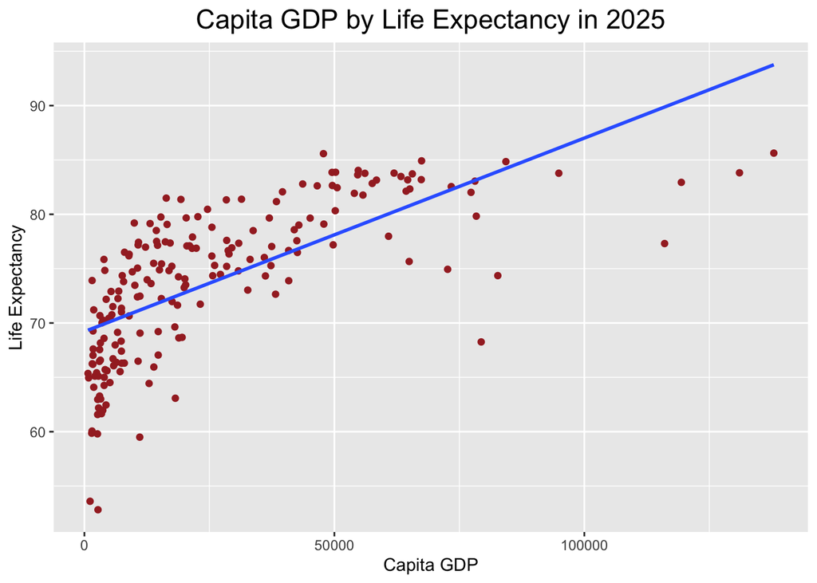

```r
gapminder %>%
  filter(year==2025, !country=="Monaco") %>%
  ggplot(aes(x=gdp, y=lex))+
  geom_point(color="brown")+
  geom_smooth(method=lm, se=F)+
  labs(title="Capita GDP by Life Expectancy in 2025", x="Capita GDP", y="Life Expectancy")+
  theme(plot.title = element_text(size=rel(1.5), hjust=.5))
```

8. Which five countries have had the highest absolute GDP per capita growth over the past 50 years? Show this as a table. (Suggestion! Remove Monaco as an extreme outlier.)

```r
gapminder %>%
  filter(!country=="Monaco" & year %in% c(1975, 2025)) %>%
  select(country, year, gdp) %>%
  pivot_wider(names_from = "year",
              values_from = "gdp") %>%
  mutate(gdp_in_50ys=`2025`-`1975`) %>%
  slice_max(gdp_in_50ys, n=5)
```

```
## # A tibble: 5 × 4
##   country    `1975`  `2025` gdp_in_50ys
##   <chr>       <dbl>   <dbl>       <dbl>
## 1 Singapore  12896. 137906.     125010.
## 2 Ireland    14336. 119406.     105071.
## 3 Luxembourg 30950. 131038.     100088.
## 4 Guyana      5071.  79371.      74300.
## 5 Norway     25513.  94896.      69382.
```

9. How does per capita GDP growth compare between these same five countries over the past 50 years? Show this as a plot.

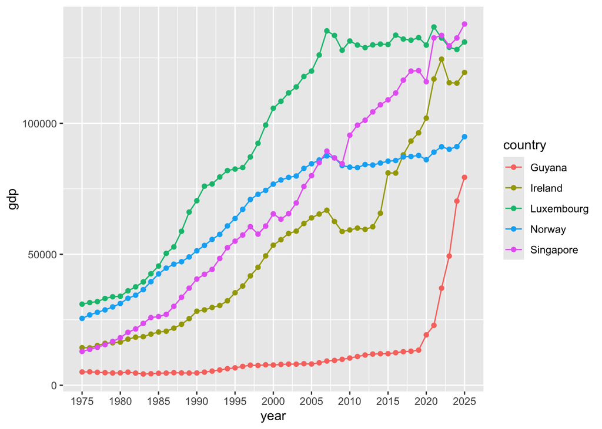

```r
gapminder %>%
  filter(between(year, 1975, 2025) & c(country=="Guyana" | country=="Ireland" | country=="Luxembourg" | country=="Norway" | country=="Singapore")) %>%
  select(country, year, gdp) %>%
  ggplot(aes(x=year, y=gdp, color=country))+
  geom_line()+
  geom_point()+
  scale_x_continuous(breaks=seq(1975, 2025, by=5))
```

10. Do one analysis of your choice that includes a table and plot as outputs.

```r
gapminder %>%
  filter(year==2025) %>%
  select(country, pop, gdp) %>%
  group_by(country) %>%
  arrange(desc(gdp))
```

```
## # A tibble: 195 × 3
## # Groups:   country [195]
##    country           pop     gdp
##    <chr>           <dbl>   <dbl>
##  1 Monaco          38341 475911.
##  2 Singapore     5870750 137906.
##  3 Luxembourg     680453 131038.
##  4 Ireland       5308039 119406.
##  5 Qatar         3115889 116057.
##  6 Norway        5623071  94896.
##  7 Switzerland   8967407  84311.
##  8 Brunei         466330  82693.
##  9 Guyana         835986  79371.
## 10 USA         347275807  78389.
## # ℹ 185 more rows
```

```r
gapminder %>%
  filter(year==1925) %>%
  select(country, pop, gdp) %>%
  group_by(country) %>%
  arrange(desc(gdp))
```

```
## # A tibble: 195 × 3
## # Groups:   country [195]
##    country           pop    gdp
##    <chr>           <dbl>  <dbl>
##  1 USA         116193761 14890.
##  2 Australia     5799933 11820.
##  3 New Zealand   1358099 11265.
##  4 Switzerland   3954755 11198.
##  5 UK           46320599 10949.
##  6 Netherlands   7349462 10709.
##  7 Belgium       7780894  9933.
##  8 Monaco          24818  9649.
##  9 Luxembourg     283715  9545.
## 10 Denmark       3394424  9319.
## # ℹ 185 more rows
```

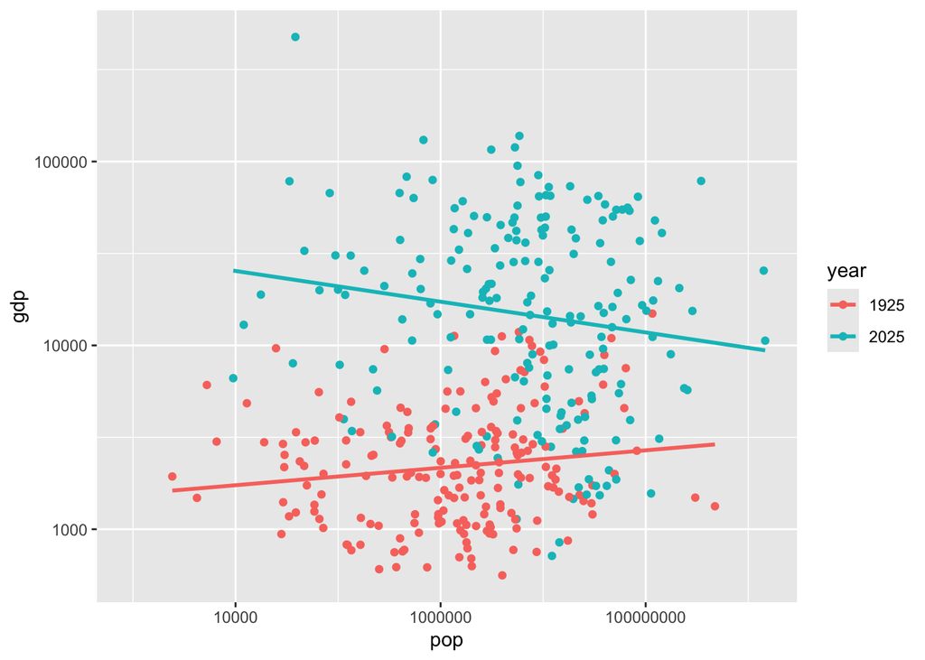

```r
gapminder %>%
  filter(year %in% c(1925, 2025))%>%
  mutate(year=factor(year)) %>%
  ggplot(aes(x=pop, y=gdp, color=year))+
  geom_point()+
  geom_smooth(method=lm, se=F)+
  scale_x_log10()+
  scale_y_log10()
```

Generally, the population size and GDP per capita are not directly proportional in either year. There is no direct relationship between population size and GDP per capita.

## Knit and Upload

Please knit your work as an .html file and upload to Canvas. Homework is due before the start of the next lab. No late work is accepted. Make sure to use the formatting conventions of RMarkdown to make your report neat and clean!